# Laboratory 6

Simulation, examples and exercises

L.Egidi

Spring 2018

# Generalized additive models (GAM)

A generalized additive model (GAM) is a generalized linear model (GLM) in which the linear predictor is given by a user specified sum of smooth functions of the covariates plus a conventional parametric component of the linear predictor. Given $\mu_i=E[Y_i]$, a simple example is:

$$\log(\mu_i)= \beta_0+\sum_{j=1}^{p}s_j(x_{ij})+\epsilon_i, \ i=1,\ldots,n,$$
where the dependent variable $Y_i \sim \mathsf{Poisson}(\mu_i)$ and $s_j$ are smooth functions of covariates $x_j$. GAM models imply the following **likelihood penalization**

$$l(\boldsymbol{\beta}, \boldsymbol{s})-\lambda R(\boldsymbol{s}),$$

where $R(\boldsymbol{s})$ is a measure of roughness.

- if $\lambda \rightarrow \infty \Rightarrow$ **maximal smoothness**. The fitted curve $s(\cdot)$ is a straight line. The *effective number of parameters* associated to the predictor $x_j$ is 1. No need for a smooth function.
- if $\lambda \rightarrow 0\Rightarrow$ **no smoothness**. No penalty is considered and the *effective number of parameters* associated to the predictor $x_j$ is greater than 1.

## Trees dataset

As an example, consider the simple dataset `trees`, where we have measurements of the girth, height and volume of timber in 31 felled black cherry trees. Note that girth is the diameter of the tree (in inches) measured at 4 ft 6 in above the ground. First of all, we use the `pairs` plot for checking possible correlations between the three variables.

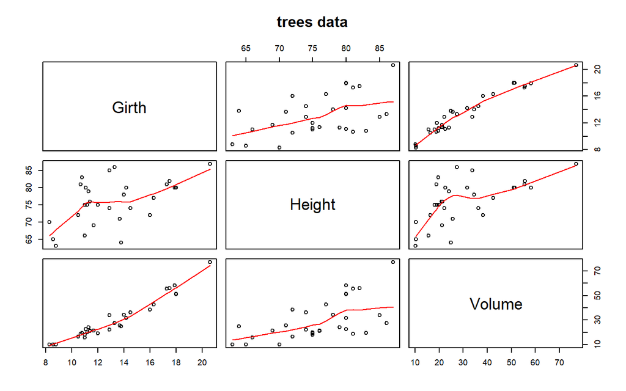

```r
library(mgcv)
pairs(trees, panel = panel.smooth, main = "trees data")
```

In order to give a general idea about the GAM flexibility, we may start with one predictor. We could fit a simple Generalized Linear Model (GLM), and a GAM model $Y_{i} \sim \mathsf{Gamma}(\mu_i, \phi)$, such that:

$$\begin{align*}
\log(\mu_i)= & \beta_0+\beta_1 \mathsf{Height}_i\\
\log(\mu_i)= & \beta_0+ s_1(\mathsf{Height}_i),
\end{align*}$$

for $i=1,\ldots,n$. The question we pose is whether the GLM structure is good enough for fitting these data. We could start by printing the output of the GAM model; then, we may plot the predicted values for both the models.

```r
glm.1 <- glm(Volume ~ Height, family = Gamma(link=log), data=trees)
gam.1 <- gam(Volume ~ s(Height),  family=Gamma(link=log),
  data=trees)
summary(gam.1)
```

```
##
## Family: Gamma
## Link function: log
##
## Formula:
## Volume ~ s(Height)
##
## Parametric coefficients:
##             Estimate Std. Error t value Pr(>|t|)
## (Intercept)  3.34970    0.07236   46.29   <2e-16 ***
## ---
## Signif. codes:  0 '***' 0.001 '**' 0.01 '*' 0.05 '.' 0.1 ' ' 1
##
## Approximate significance of smooth terms:
##           edf Ref.df     F  p-value
## s(Height)   1      1 22.97 3.68e-05 ***
## ---
## Signif. codes:  0 '***' 0.001 '**' 0.01 '*' 0.05 '.' 0.1 ' ' 1
##
## R-sq.(adj) =  0.348   Deviance explained = 42.6%
## GCV = 0.17591  Scale est. = 0.1623    n = 31
```

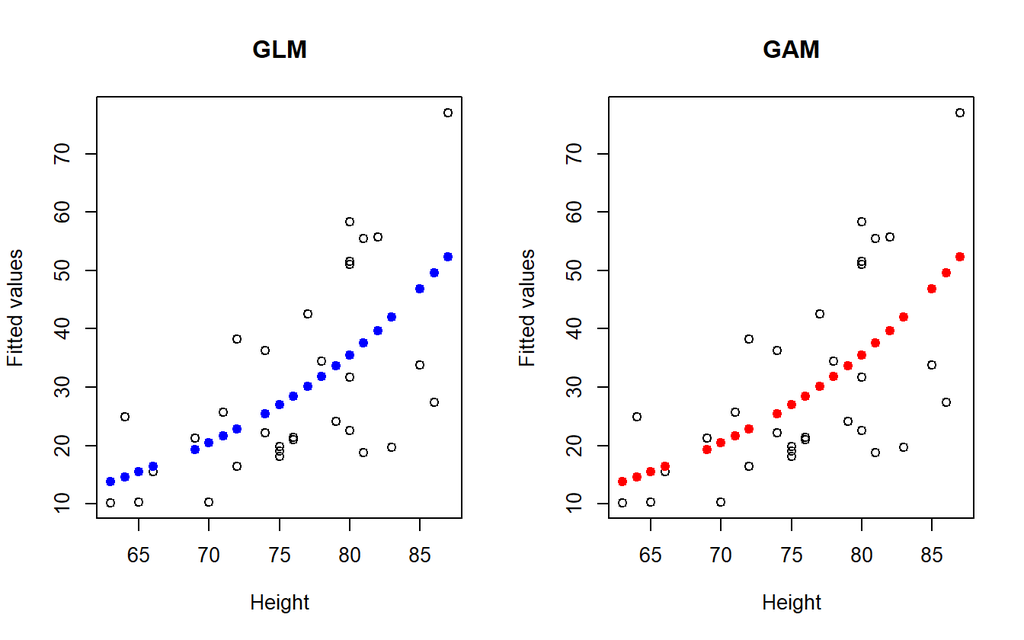

```r
par(mfrow=c(1,2))
plot(trees$Height, trees$Volume, xlab="Height", ylab="Fitted values", main ="GLM")
points(trees$Height, glm.1$fitted.values, col="blue", bg=3, pch=19)
plot(trees$Height, trees$Volume, xlab="Height", ylab="Fitted values", main ="GAM")
points(trees$Height, gam.1$fitted.values, col="red", bg=2, pch=19)
```

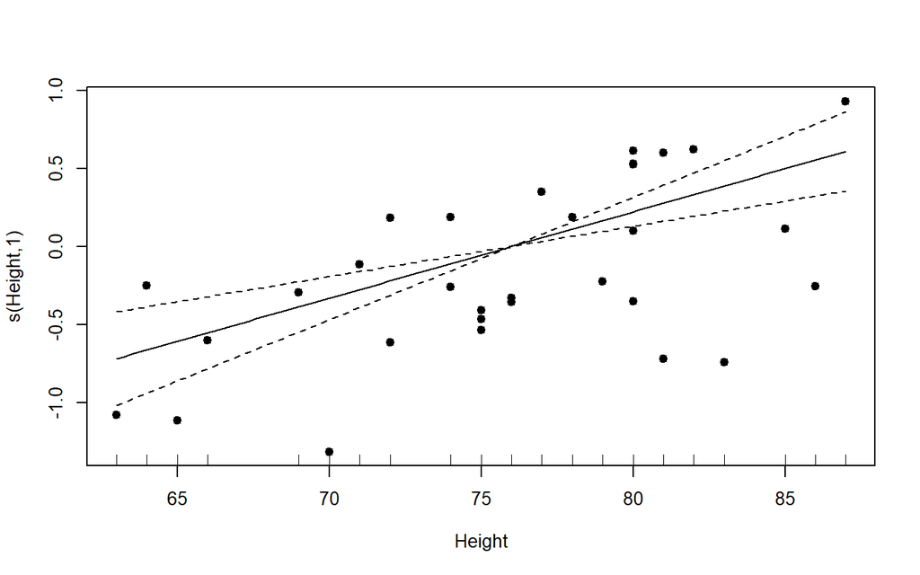

```r
par(mfrow=c(1,1))
plot(gam.1,residuals=TRUE,pch=19)
```

By the joint analysis of the summary output—look at the value `edf=1`—the prediction plots and the final plot displaying $s(\mathsf{Height})$ versus $\mathsf{Height}$, we may conclude that this simple single predictor framework may be well explained by a GLM approach.

Consider now to add the predictor $\mathsf{Girth}$, and take the same model as before, $Y_{i}=\mathsf{Volume}_i\sim \mathsf{Gamma}(\mu_i, \phi)$, then:

$$\log(\mu_i)=s_1(\mathsf{Height}_i)+s_2(\mathsf{Girth}_i).$$
Analogously as before, we fit the GLM and the GAM model. We plot together the fitted values and we separately analyze the smooth terms $s_1(\mathsf{Height})$ and $s_2(\mathsf{Girth})$.

```r
glm.2<-glm(Volume ~ Girth + Height, family = Gamma(link=log),
  data=trees)
gam.2 <- gam(Volume ~ s(Height) + s(Girth), family=Gamma(link=log),
  data=trees)
summary(gam.2)
```

```
##
## Family: Gamma
## Link function: log
##
## Formula:
## Volume ~ s(Height) + s(Girth)
##
## Parametric coefficients:
##             Estimate Std. Error t value Pr(>|t|)
## (Intercept)  3.27570    0.01492   219.6   <2e-16 ***
## ---
## Signif. codes:  0 '***' 0.001 '**' 0.01 '*' 0.05 '.' 0.1 ' ' 1
##
## Approximate significance of smooth terms:
##             edf Ref.df      F  p-value
## s(Height) 1.000  1.000  31.32 3.92e-06 ***
## s(Girth)  2.422  3.044 219.28  < 2e-16 ***
## ---
## Signif. codes:  0 '***' 0.001 '**' 0.01 '*' 0.05 '.' 0.1 ' ' 1
##
## R-sq.(adj) =  0.973   Deviance explained = 97.8%
## GCV = 0.0080824  Scale est. = 0.006899  n = 31
```

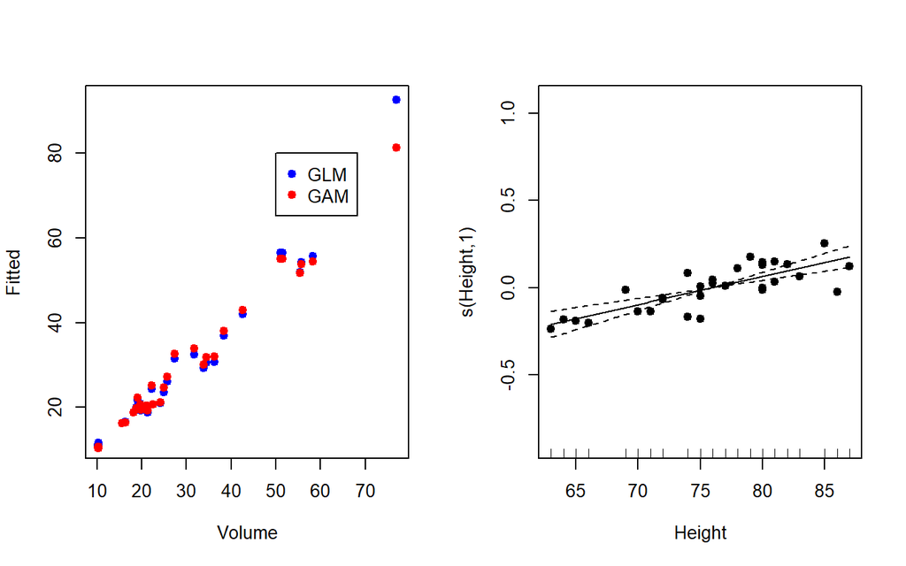

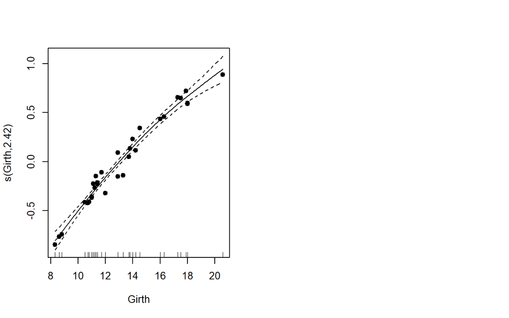

```r
par(mfrow=c(1,2))
plot(trees$Volume, glm.2$fitted.values, col="blue", bg=3, pch=19, xlab ="Volume", ylab="Fitted")
points(trees$Volume, gam.2$fitted.values, col="red", bg=2, pch=19)
legend(50, 80, pch=19, col=c("blue", "red"), c("GLM", "GAM"))

plot(gam.2, residuals =TRUE, pch =19)
```

The output reports an `edf` equals 2.422 for the $\mathsf{Girth}$ predictor, meaning that a straight line could be partially inappropriate for our purposes. As a further check, we may compute the AIC for the four proposed models:

```r
AIC(glm.1, gam.1, glm.2, gam.2)
```

```
##             df      AIC
## glm.1 3.000000 239.6724
## gam.1 3.000009 239.6724
## glm.2 4.000000 151.0081
## gam.2 5.422254 142.8559
```

The AIC for the single predictor models coincide. The AIC dramaticaly decreases when considering the second predictor, with the GAM model favorable than the GLM model.

```
##                 df      AIC
## gam.2     5.422254 142.8559
## gam.2.opt 5.422254 142.8559
```

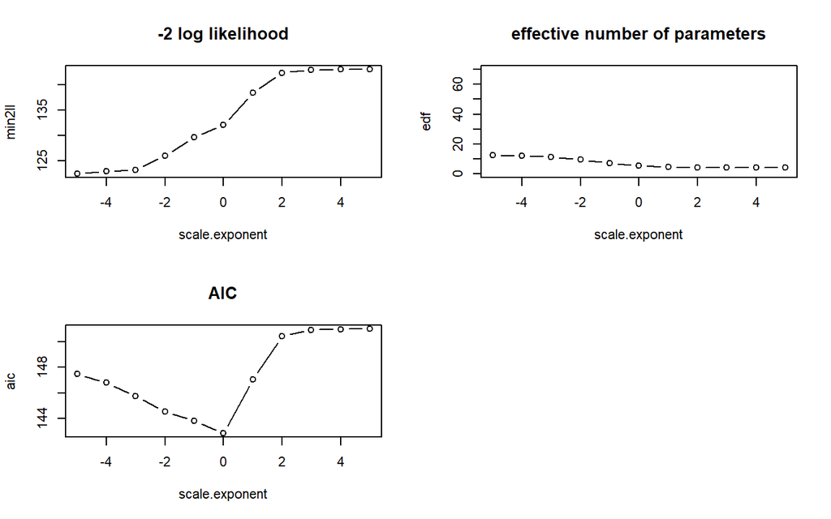

```r
#extract the value
sp <- gam.2$sp

tuning.scale<-c(1e-5,1e-4,1e-3,1e-2,1e-1,1e0,1e1,1e2,
  1e3,1e4,1e5)
scale.exponent <- log10(tuning.scale)
n.tuning <- length(tuning.scale)
edf <- rep(NA,n.tuning)
min2ll <- rep(NA,n.tuning)
aic <- rep(NA,n.tuning)


for (i in 1:n.tuning) {
  gamobj <- gam(Volume ~ s(Height) + s(Girth), family=Gamma(link=log),
    data=trees, sp=tuning.scale[i]*sp)
  min2ll[i]<--2*logLik(gamobj)
  edf[i]<-sum(gamobj$edf)+1
  aic[i]<-AIC(gamobj)
}

par(mfrow=c(2,2))
plot(scale.exponent,min2ll,type="b",main="-2 log likelihood")
plot(scale.exponent,edf,ylim=c(0,70),type="b",main="effective number of parameters")
plot(scale.exponent,aic,type="b",main="AIC")

# find the minimum
min.aic<-1e100
opt.tuning.scale<-NULL
for (i in 1:n.tuning) {
  if (aic[i]<min.aic) {
    min.aic<-aic[i]
  opt.tuning.scale<-tuning.scale[i]
  }
  }
opt.sp<-opt.tuning.scale*sp

# fitting the final model with the optimal level of smoothing

gam.2.opt <- gam(Volume ~ s(Height)+s(Girth), family=Gamma(link=log),data=trees, sp=opt.sp)

AIC(gam.2, gam.2.opt)
```

## Exercise: Ozone data

In the package `faraway`—install it on your laptpop—dataset `ozone` contains atmospheric ozone concentration and meteorology in the Los Angeles Basin in 1976.

1- Propose a GAM model for this dataset, modelling the ozone concentration `O3` as your dependent variable. Your final model should include only the influential predictors. What can you conclude about the smoothing terms?

2- Provide the optimal degree of smoothing for $\lambda$ through BIC.

3- Compute the AIC between your final model and an equivalent GLM formulation. Which model yields the lowest AIC? And what do you conclude then?

# Mixed models

The term *mixed* refers to the presence of both fixed and random coefficients in the model. In Bayesian inference, this distinction sounds as no relevant. Mixed models may be seen as a compromise between two extremes: **complete pooling** and **no pooling**.

Complete pooling: modelling the units all together.

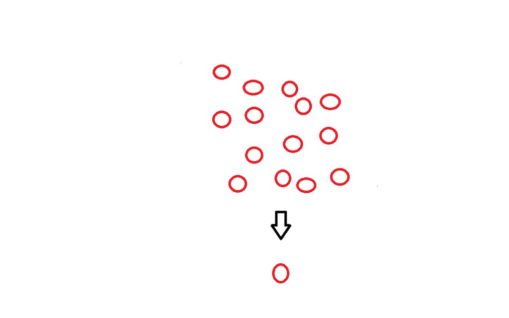

No pooling: separate model for each unit.

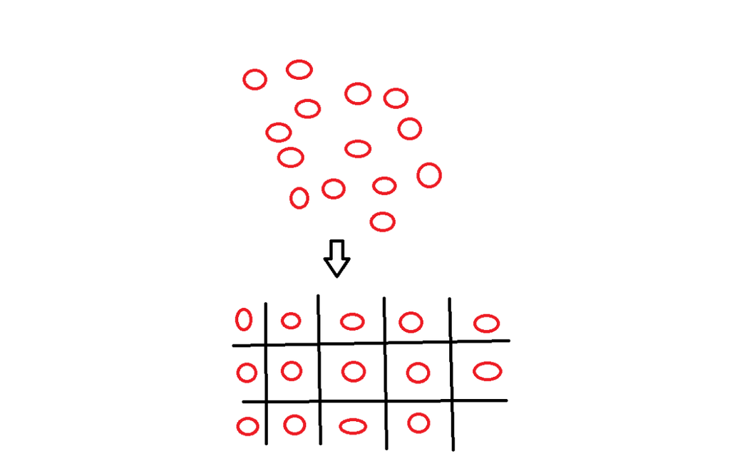

Mixed/multilevel models: borrowing strengths from the two extremes.

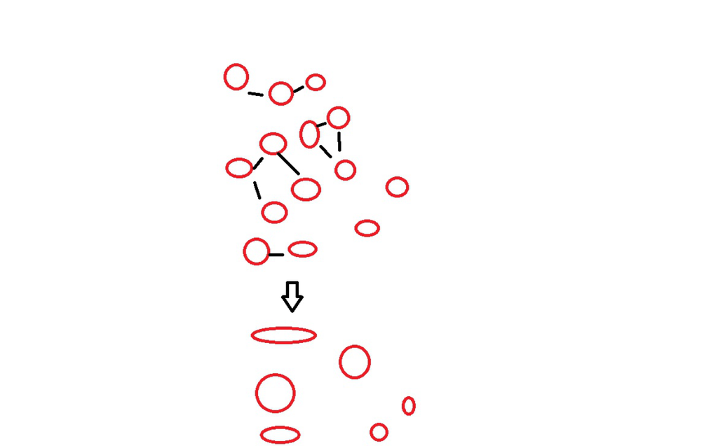

## State-level opinions from national polls

We study now the voters intentions in USA arising from dozens of national opinion polls conducted by media organizations before the 1988 presidential elections (the Republican Bush versus the Democrat Dukakis). For a complete analysis of these data, see Gelman and Hill (2006). It is desirable to estimate opinions at the levels of individual states as well as for the entire country. Then, a mixed model is appropriate for our purposes. The dependent variable $Y_i$ denotes the binary vote intention, equals 1 if the $i$-th vote is for the Republican candidate Bush, 0 if for the Democrat candidate Dukakis. Then, our model is a multilevel logistic regression such that:

$$Pr(Y_i=1)=\text{logit}^{-1}(x_i\beta)$$

Potential predictors include the state index $j[i]$ and the demographics: sex, ethnicity, age and education.

Ultimate goal: we want to estimate from the polls the raw proportion of voters for the Republicans for each state $j$, $\theta_j$.

The dataset `polls.dat` contains the results of seven-year polls. We import and munge data, by using only the last year survey:

```r
library ("arm")
library("R2WinBUGS")

data (state)                  # "state" is an R data file
state.abbr <- c (state.abb[1:8], "DC", state.abb[9:50])
dc <- 9
not.dc <- c(1:8,10:51)
region <- c(3,4,4,3,4,4,1,1,5,3,3,4,4,2,2,2,2,3,3,1,1,1,2,2,3,2,4,2,4,1,1,4,1,3,2,2,3,4,1,1,3,2,3,3,4,1,3,4,1,2,4)

# Load in data from the CBS polls in 1988
# Data are at http://www.stat.columbia.edu/~gelman/arm/examples/election88
library (foreign)
polls <- read.dta ("polls.dta")
attach.all (polls)

# Select just the data from the last survey (#9158)
table (survey)                # look at the survey id's
```

```
## survey
##  9152  9153  9154  9155 9156a 9156b  9157  9158
##  1611  1653  1833  1943   684  1478  2149  2193
```

```r
ok <- survey==9158            # define the condition
polls.subset <- polls[ok,]    # select the subset of interest
attach.all (polls.subset)     # attach the subset
write.table (polls.subset, "polls.subset.dat")

print (polls.subset[1:5,])
```

```
##          org year survey bush state edu age female black weight
## 11352 cbsnyt    7   9158   NA     7   3   1      1     0    923
## 11353 cbsnyt    7   9158    1    39   4   2      1     0    558
## 11354 cbsnyt    7   9158    0    31   2   4      1     0    448
## 11355 cbsnyt    7   9158    0     7   3   1      1     0    923
## 11356 cbsnyt    7   9158    1    33   2   2      1     0    403
```

```r
# define other data summaries
y <- bush                  # 1 if support bush, 0 if support dukakis
n <- length(y)             # of survey respondents
n.age <- max(age)          # of age categories
n.edu <- max(edu)          # of education categories
n.state <- max(state)      # of states
n.region <- max(region)    # of regions

# compute unweighted and weighted averages for the U.S.
ok <- !is.na(y)                                    # remove the undecideds
cat ("national mean of raw data:", round (mean(y[ok]==1), 3), "\n")
```

```
## national mean of raw data: 0.558
```

```r
cat ("national weighted mean of raw data:",
     round (sum((weight*y)[ok])/sum(weight[ok]), 3), "\n")
```

```
## national weighted mean of raw data: 0.543
```

```r
# compute weighted averages for the states
raw.weighted <- rep (NA, n.state)
names (raw.weighted) <- state.abbr
for (i in 1:n.state){
  ok <- !is.na(y) & state==i
  raw.weighted[i] <- sum ((weight*y)[ok])/sum(weight[ok])
}

#load in 1988 election data as a validation check
 election88 <- read.csv2 ("elec_outcome.csv", sep=";", header=TRUE)
 outcome <- as.numeric(as.vector(election88$results))

# load in 1988 census data
census <- read.dta ("census88.dta")

# also include a measure of previous vote as a state-level predictor
presvote <- read.dta ("presvote.dta")
attach (presvote)
v.prev <- presvote$g76_84pr
not.dc <- c(1:8,10:51)
```

We propose three alternative models:

$\mathcal{M}_1$: **Varying-intercept model** including sex and black race.

$$\begin{align*}
Pr(Y_i=1)= & \text{logit}^{-1}(\alpha_{j[i]}+\beta^{\text{female}}\text{female}_i+\beta^{\text{black}}\text{black}_i), \ \ i=1,\ldots,n \\
\alpha_j \sim & \mathcal{N}(\mu_{\alpha}, \sigma^2_{\text{state}}), \ \ j=1,\ldots, 51
\end{align*}$$

$\mathcal{M}_2$: **Varying-intercept and slope** model

$$\begin{align*}
Pr(Y_i=1)= & \text{logit}^{-1}(\alpha_{j[i]}+\beta_{j[i]}^{\text{female}}\text{female}_i+\beta^{\text{black}}\text{black}_i), \ \ i=1,\ldots,n \\
\binom{\alpha_{j}}{\beta_{j}} \sim & \mathcal{N}\left(\binom{\mu_{\alpha}}{\mu_{\beta}}, \left(\begin{matrix} \sigma^{2}_{\alpha} & \rho \sigma_{\alpha}\sigma_{\beta}\\ \rho\sigma_{\alpha}\sigma_{\beta} & \sigma^2_{\beta} \end{matrix} \right) \right ), \ \ j=1,\ldots, 51
\end{align*}$$

$\mathcal{M}_3$: **Fuller varying-intercept model**, including:

- the Republican votes in the previous elections;
- a macro-distinction in five regions of the Country (Northeast, Midwest, South, West, and D.C.);
- an interaction between sex and race;
- an interaction between age end education.

$$\begin{align*}
Pr(Y_i=1)= & \text{logit}^{-1}(\alpha^{\text{state}}_{j[i]}+\alpha^{\text{age}}_{k[i]}+\alpha^{\text{edu}}_{l[i]}+\alpha^{\text{age.edu}}_{k[i], l[i]}+\beta^{\text{female}}\text{female}_i+\\
&+\beta^{\text{black}}\text{black}_i+\beta^{\text{female.black}}\text{female}_i\text{black}_i), \ \ i=1,\ldots,n \\
\alpha_j \sim & \mathcal{N}(\alpha^{\text{region}}_{m[j]}+\beta^{\text{v.prev}}\text{v.prev}_j, \sigma^2_{\text{state}}), \ \ j=1,\ldots, 51\\
\alpha^{\text{age}}_k \sim & \mathcal{N}(0, \sigma^2_{\text{age}}), \ \ k=1,\ldots, 4\\
\alpha^{\text{edu}}_l \sim & \mathcal{N}(0, \sigma^2_{\text{edu}}), \ \ l=1,\ldots, 4\\
\alpha^{\text{age.edu}}_{k,l} \sim & \mathcal{N}(0, \sigma^2_{\text{age.edu}}), \ \ k=1,\ldots, 4, \ \ l=1,\ldots,4\\
\alpha^{\text{region}}_m \sim & \mathcal{N}(0, \sigma^2_{\text{region}}), \ \ m=1,\ldots, 5\\
\end{align*}$$

### Fitting the model: classical approach

Fitting a mixed model according to a classical approach is made possible by use of function `glmer` of the `lme4` package.

```r
library(lme4)
## Multilevel logistic regression
M1 <- glmer (y ~ black + female + (1 | state), family=binomial(link="logit"))
display (M1)
```

```
## glmer(formula = y ~ black + female + (1 | state), family = binomial(link = "logit"))
##             coef.est coef.se
## (Intercept)  0.45     0.10
## black       -1.74     0.21
## female      -0.10     0.10
##
## Error terms:
##  Groups   Name        Std.Dev.
##  state    (Intercept) 0.41
##  Residual             1.00
## ---
## number of obs: 2015, groups: state, 49
## AIC = 2666.7, DIC = 2531.5
## deviance = 2595.1
```

The first part of the summary gives the estimate of the average intercept (random effect), the coefficients for `black` and `female` (fixed effects) and their standard errors. The estimate for $\sigma_{\text{state}}$ is 0.4, while the overdispersion parameter is 1 (no overdispersion), since logistic regression with binary data cannot be overdispersed. In order to visualize the random effects, we could plot them along the states. With the command `coef(M1)` we extract the model coefficients, and we can plot the random coefficients for the states.

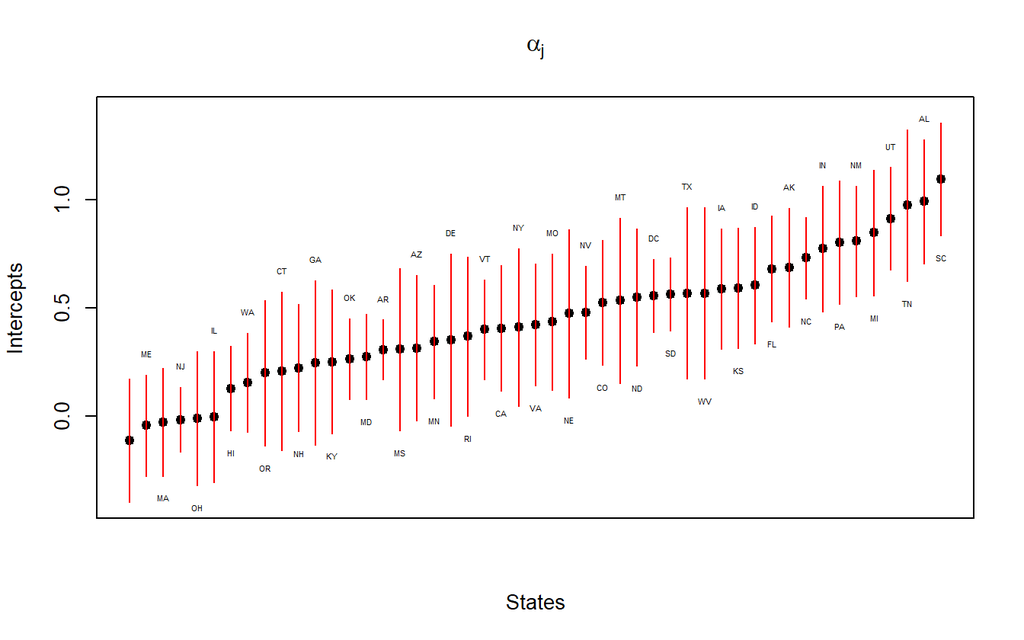

```r
int_ord <- sort(coef(M1)$state[,1], index.return=TRUE)$x
ord <- sort(coef(M1)$state[,1], index.return=TRUE)$ix
state.abbr.ord <- state.abbr[ord]
se_ord <- se.ranef(M1)$state[ord]
par(xaxt="n")
plot( 1:49, int_ord, ylim=c(-0.4,1.4), pch=19, bg=2, xlab="States",
  ylab="Intercepts", main =expression(alpha[j]))
for (h in 1:49){
segments(h, int_ord[h]-se_ord[h], h, int_ord[h]+se_ord[h], col="red")
  is.wholenumber <-
    function(x, tol = .Machine$double.eps^0.5)
      abs(x - round(x)) < tol
  if (is.wholenumber(h/2)){
  text(h, int_ord[h]+se_ord[h]+0.1, state.abbr.ord[h], cex=0.4)}else{
  text(h, int_ord[h]-se_ord[h]-0.1, state.abbr.ord[h], cex=0.4)
  }
}
```

Now we fit the varying-intercept and slope model:

```r
M2 <- glmer (y ~ black + female + (1+ female | state),
  family=binomial(link="logit"))
display (M2)
```

```
## glmer(formula = y ~ black + female + (1 + female | state), family = binomial(link = "logit"))
##             coef.est coef.se
## (Intercept)  0.46     0.11
## black       -1.74     0.21
## female      -0.12     0.10
##
## Error terms:
##  Groups   Name        Std.Dev. Corr
##  state    (Intercept) 0.50
##           female      0.15     -1.00
##  Residual             1.00
## ---
## number of obs: 2015, groups: state, 49
## AIC = 2669.4, DIC = 2529.6
## deviance = 2593.5
```

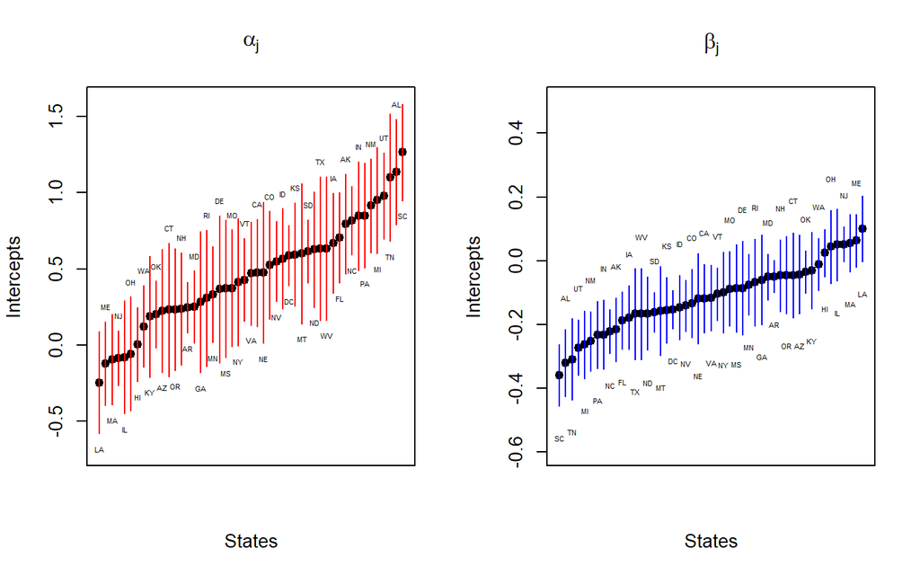

```r
int_ord2 <- sort(coef(M2)$state[,1], index.return=TRUE)$x
ord2 <- sort(coef(M2)$state[,1], index.return=TRUE)$ix
state.abbr.ord2 <- state.abbr[ord2]
se_ord2 <- se.ranef(M2)$state[ord2,1]
par(xaxt="n", mfrow=c(1,2))
plot( 1:49, int_ord2, ylim=c(-0.7,1.6), pch=19, bg=2, xlab="States",
  ylab="Intercepts", main =expression(alpha[j]))
for (h in 1:49){
segments(h, int_ord2[h]-se_ord2[h], h,
  int_ord2[h]+se_ord2[h], col="red")
  is.wholenumber <-
    function(x, tol = .Machine$double.eps^0.5)
      abs(x - round(x)) < tol
  if (is.wholenumber(h/2)){
  text(h, int_ord2[h]+se_ord2[h]+0.1,
    state.abbr.ord2[h], cex=0.4)}else{
  text(h, int_ord2[h]-se_ord2[h]-0.1,
    state.abbr.ord2[h], cex=0.4)
  }
}

int_ord2.slope <- sort(coef(M2)$state[,3], index.return=TRUE)$x
ord2.slope <- sort(coef(M2)$state[,3], index.return=TRUE)$ix
state.abbr.ord2.slope <- state.abbr[ord2.slope]
se_ord2.slope <- se.ranef(M2)$state[ord2.slope,2]
plot( 1:49, int_ord2.slope, ylim=c(-0.6,0.5), pch=19, bg=2,
  xlab="States",
  ylab="Intercepts", main =expression(beta[j]))
for (h in 1:49){
segments(h, int_ord2.slope[h]-se_ord2.slope[h], h,
  int_ord2.slope[h]+se_ord2.slope[h], col="blue")
  is.wholenumber <-
    function(x, tol = .Machine$double.eps^0.5)
      abs(x - round(x)) < tol
  if (is.wholenumber(h/2)){
  text(h, int_ord2.slope[h]+se_ord2.slope[h]+0.1,
    state.abbr.ord2.slope[h], cex=0.4)}else{
  text(h, int_ord2.slope[h]-se_ord2.slope[h]-0.1,
    state.abbr.ord2.slope[h], cex=0.4)
  }
}
```

Now let’s fit the fuller model.

```r
age.edu <- n.edu*(age-1) + edu
region.full <- region[state]
v.prev.full <- v.prev[state]

 # fit the model
M3 <- glmer (y ~ black + female + black:female +
    v.prev.full + (1 | age) +
  (1 | edu) + (1 | age.edu) + (1 | state) + (1 | region.full),
  family=binomial(link="logit"))
display (M3)
```

```
## glmer(formula = y ~ black + female + black:female + v.prev.full +
##     (1 | age) + (1 | edu) + (1 | age.edu) + (1 | state) + (1 |
##     region.full), family = binomial(link = "logit"))
##              coef.est coef.se
## (Intercept)  -2.18     0.82
## black        -1.65     0.33
## female       -0.09     0.10
## v.prev.full   4.72     1.46
## black:female -0.17     0.42
##
## Error terms:
##  Groups      Name        Std.Dev.
##  state       (Intercept) 0.20
##  age.edu     (Intercept) 0.13
##  region.full (Intercept) 0.31
##  edu         (Intercept) 0.13
##  age         (Intercept) 0.05
##  Residual                1.00
## ---
## number of obs: 2015, groups: state, 49; age.edu, 16; region.full, 5; edu, 4; age, 4
## AIC = 2653.7, DIC = 2534.7
## deviance = 2584.2
```

Let’s check the AIC for the three models:

```r
AIC(M1, M2, M3)
```

```
##    df      AIC
## M1  4 2666.660
## M2  6 2669.376
## M3 10 2653.652
```

$\mathcal{M}_3$ reports the lowest AIC, and is then our selected model. Some considerations about its estimates:

- the coefficient for `black` is -1.6. Approximately, African-American men were 40% less likely than other men to support Bush, after controlling for age, education, and state.
- the coefficient for `v.prev.full` is 4.72, suggesting that a 1% difference in a state’s support for Republican candidates in previous elections mapped to a predicted 1.18% difference in support for Bush in 1988.
- very little variation is found among age groups or education groups after controlling for the other predictors in the model (see plots below).

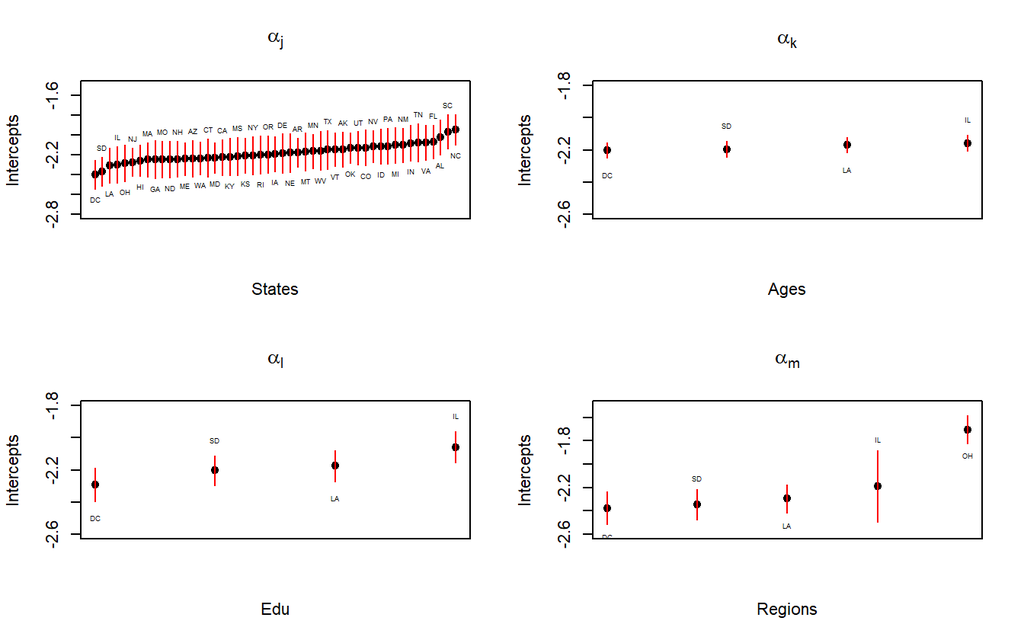

### Fitting the model: Bayesian approach

In order to assess for uncertainty in the random effects variability, fitting the previous models according to a Bayesian approach could be more appropriate. The function `stan_glmer` in the `rstanarm` package allows for fitting the model above with the same syntax of `glmer`, but taking advantage of an underlying `Stan` program, already launched by the function. The user has just to type the following commands:

```r
library(rstanarm)
library(loo)

M1.bayes <- stan_glmer (y ~ black + female + (1 | state),
  family=binomial(link="logit"))

M2.bayes <- stan_glmer (y ~ black + female +
    (1+ female | state),
  family=binomial(link="logit"))

M3.bayes <- stan_glmer (y ~ black + female +
    black:female + v.prev.full + (1 | age) +
  (1 | edu) + (1 | age.edu) + (1 | state) + (1 | region.full),
  family=binomial(link="logit"))
```

In order to compare our models as before, we compute an extension of the AIC based on cross validation via `loo` package.

```r
#compute pointwise lok-likelihood
lpd1 <- log_lik(M1.bayes)
loo1 <- loo(lpd1)
lpd2 <- log_lik(M2.bayes)
loo2 <- loo(lpd2)
lpd3 <- log_lik(M3.bayes)
loo3 <- loo(lpd3)

c(loo1$looic, loo2$looic, loo3$looic)
```

```
## [1] 2649.499 2651.858 2635.061
```

As in classical approach, $\mathcal{M}_3$ registers the lowest AIC and is favorable with respect to the other models. We may print the results:

```r
print(M3.bayes)
```

```
## stan_glmer
##  family:       binomial [logit]
##  formula:      y ~ black + female + black:female + v.prev.full + (1 | age) +
##     (1 | edu) + (1 | age.edu) + (1 | state) + (1 | region.full)
##  observations: 2015
## ------
##              Median MAD_SD
## (Intercept)  -2.2    0.9
## black        -1.7    0.3
## female       -0.1    0.1
## v.prev.full   4.8    1.5
## black:female -0.2    0.4
##
## Error terms:
##  Groups      Name        Std.Dev.
##  state       (Intercept) 0.23
##  age.edu     (Intercept) 0.16
##  region.full (Intercept) 0.60
##  edu         (Intercept) 0.32
##  age         (Intercept) 0.23
## Num. levels: state 49, age.edu 16, region.full 5, edu 4, age 4
##
## Sample avg. posterior predictive distribution of y:
##          Median MAD_SD
## mean_PPD 0.6    0.0
##
## ------
## For info on the priors used see help('prior_summary.stanreg').
```

We immediately notice that the obtained results are quite similar with those obtained under the classical approach. Now, we may compute the final proportion $\theta_j$ as estimated by $\mathcal{M}_3$ and plot them against the actual proportions of the 1988 presidential elections.

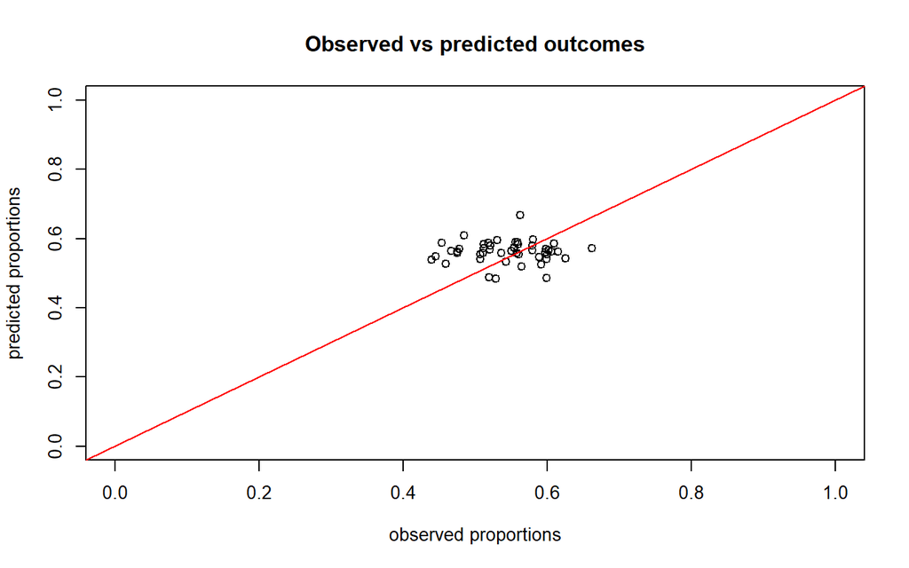

```r
#build state proportions

invlogit <- function(x){ 1/(1+exp(-x))}
lin.pred <- M3.bayes$linear.predictors[!is.na(y)]
prob.pred <- invlogit(lin.pred)
state.pred <- state[!is.na(y)]
prob.pred.list <- list()
prob.pred.aggr <- c()
  for (h in 1:length(unique(state.pred))){
  prob.pred.list[[h]] <- prob.pred[state.pred==h]
  prob.pred.aggr[h] <- mean( prob.pred.list[[h]], na.rm =TRUE)
  }

plot(outcome[-c(2,11,12)]/100, prob.pred.aggr[!is.nan(prob.pred.aggr)], xlab="observed proportions", ylab="predicted proportions", xlim=c(0,1), ylim=c(0,1), main ="Observed vs predicted outcomes")
abline(a=0, b=1, col="red")
```

The model seems to make good predictions, supporting the Bush win. George Bush actually won the 1988 elections with a global 53.37 % proportion.

# MARS: Multivariate Adaptive Regression Splines

Mars is an adaptive procedure for regression, and is well suited for high-dimensional (i.e., a large number of inputs). It is a non-parametric regression technique and can be seen as an extension of linear models that automatically models nonlinearities and interactions between variables.

MARS build models of the form:

$$\hat{f}(x)=\sum_{i=1}^{k}c_iB_i(x)$$

Each basis function $B_{i}(x)$ takes one of the following three forms:

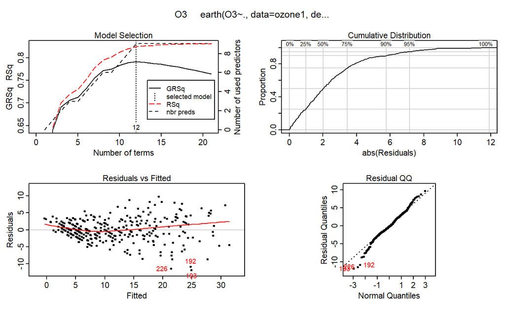

```r
library(earth)
data(ozone1)
earth.mod <- earth(O3 ~ ., data=ozone1, degree=2)
ev <- evimp(earth.mod, trim=FALSE)
plot(earth.mod)
```

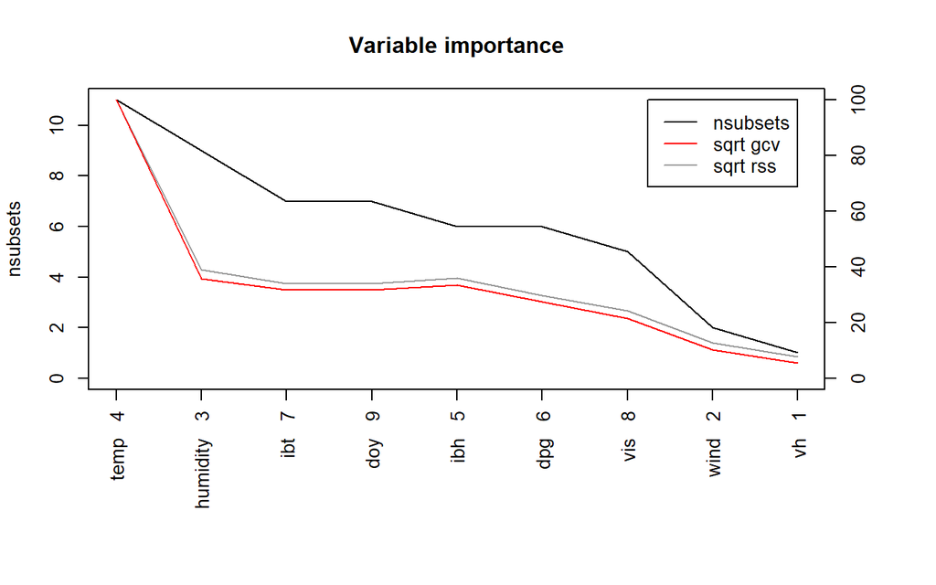

```r
plot(ev)
```

```r
print(ev)
```

```
##          nsubsets   gcv    rss
## temp           11 100.0  100.0
## humidity        9  35.7   38.9
## ibt             7  31.6   34.0
## doy             7  31.6   34.0
## ibh             6  33.4>  36.0>
## dpg             6  27.5   29.8
## vis             5  21.4   24.1
## wind            2  10.3   12.6
## vh              1   5.3    7.7
```

```r
summary(earth.mod)
```

```
## Call: earth(formula=O3~., data=ozone1, degree=2)
##
##                             coefficients
## (Intercept)                   13.2169900
## h(temp-58)                     0.3726072
## h(194-ibt)                    -0.0455100
## h(200-vis)                     0.0222462
## h(96-doy)                     -0.1223029
## h(doy-96)                     -0.0240235
## h(5730-vh) * h(temp-58)       -0.0104496
## h(wind-7) * h(200-vis)        -0.0180898
## h(55-humidity) * h(temp-58)   -0.0222754
## h(temp-58) * h(dpg-52)        -0.0168249
## h(temp-58) * h(52-dpg)         0.0041232
## h(1105-ibh) * h(21-dpg)       -0.0001022
##
## Selected 12 of 21 terms, and 9 of 9 predictors
## Termination condition: Reached nk 21
## Importance: temp, humidity, ibt, doy, ibh, dpg, vis, wind, vh
## Number of terms at each degree of interaction: 1 5 6
## GCV 13.40805    RSS 3693.401    GRSq 0.7917216    RSq 0.825085
```

# References

Gelman, Andrew, and Jennifer Hill. 2006. *Data Analysis Using Regression and Multilevel/Hierarchical Models*. Cambridge University Press.